# Exercise 3: Adaptive Monte Carlo Markov Chain samplers

Eawag Summer School in Environmental Systems Analysis

In this exercise we will look at different adaptive Metropolis algorithms. The aim is to get an intuition for what their “adaptations” are doing, by examining their behaviour with our simple `monod` model. You are encouraged to play with each of the adaptation parameters of each algorithm and to check how it influences the resulting sample chain.

# Define posterior distribution

You can use you own code from exercises 2 or the functions defined below. And of course you can also do the exercises with the growth model.

## R

```r
## load the monod model
source("../../models/models.r")

## read data
data.monod <- read.table("../../data/model_monod_stoch.csv", header=T)

## Logprior for model "monod": lognormal distribution
prior.monod.mean <- 0.5 * c(r_max=5, K=3, sigma=0.5)
prior.monod.sd   <- 0.5 * prior.monod.mean

logprior.monod <- function(par, mean, sd){
    sdlog <- sqrt(log(1+sd*sd/(mean*mean)))
    meanlog <- log(mean) - sdlog*sdlog/2
    return(sum(dlnorm(par, meanlog=meanlog, sdlog=sdlog, log=TRUE)))
}

## Log-likelihood for model "monod"
loglikelihood.monod <- function(y, C, par){

    ## deterministic part:
    y.det <- model.monod(par, C) # defined in `models.r`

    ## Calculate loglikelihood assuming independence:
    return( sum(dnorm(y, mean=y.det, sd=par['sigma'], log=TRUE )) )
}

## Log-posterior for model "monod"
logposterior.monod <- function(par) {
    lp <- logprior.monod(par, prior.monod.mean, prior.monod.sd)
    if(is.finite(lp)){
        return( lp + loglikelihood.monod(data.monod$r, data.monod$C, par) )
    } else {
        return(-Inf)
    }
}
```

## Julia

```julia
using DataFrames
import CSV
using Distributions
using ComponentArrays

monod_data = CSV.read("../../data/model_monod_stoch.csv", DataFrame)

## load monod model
include("../../models/models.jl");

## read data
monod_data = CSV.read("../../data/model_monod_stoch.csv", DataFrame)

# set parameters
prior_monod_mean = ComponentVector(r_max = 2.5, K=1.4, sigma=0.25);
prior_monod_sd = 0.5 .* prior_monod_mean;

## Use a lognormal distribution for all model parameters
function logprior_monod(par, m, sd)
    μ = @. log(m/sqrt(1+sd^2/m^2))
    σ = @. sqrt(log(1+sd^2/m^2))
    return sum(logpdf.(LogNormal.(μ, σ), par)) # sum because we are in the log-space
end

## Log-likelihood for model "monod"
function loglikelihood_monod(par::ComponentVector, data::DataFrame)
    y_det = model_monod(data.C, par)
    return sum(logpdf.(Normal.(y_det, par.sigma), data.r))
end

## Log-posterior for model "monod"
function logposterior_monod(par::ComponentVector)
    lp = logprior_monod(par, prior_monod_mean, prior_monod_sd)
    if !isinf(lp)
        lp += loglikelihood_monod(par, monod_data)
    end
    lp
end
```

# 1. Adaptive Metropolis with delayed rejection ★

We try the adaptive Metropolis with delayed rejection as described by ([Haario, Saksman and Tamminen (2001)](https://projecteuclid.org/euclid.bj/1080222083).

- What could you use as initial values?
- What is a meaningful initial covariance matrix for the jump distribution?
- Plot the chains and see how quick the convergence is.
- Look at 2d marginal plots. What happens in these marginal plots if you don’t cut off a burn-in or only use the beginning of the chain?

## Hints

### R

It is implemented in the function [`modMCMC`](https://www.rdocumentation.org/packages/FME/versions/1.3.6.2/topics/modMCMC) of the package [`FME`](https://cran.r-project.org/web/packages/FME/index.html). Note, this function expects the *negative* log density”, which is sometimes called *energy*. See the `modMCMC` function [documentation](https://www.rdocumentation.org/packages/FME/versions/1.3.6.2/topics/modMCMC) for details.

```r
neg.log.post <- function(par) -logposterior.monod(par)
```

Now call the `modMCMC` function and investigate the effects of the `updatecov` parameter (try values of 10, 100 and 1000), which determines how often the covariance of the jump distribution is updated, and the `ntrydr` parameter (try values of 1, 3 and 10), which determines the number of permissible jump attempts before the step is rejected. In particular, examine the first part of the chain and see how the adaptation works.

```r
AMDR <- modMCMC(
    f         = neg.log.post,
    p         = par.init,
    jump      = jump.cov,
    niter     = 10000,
    updatecov = 10,
    ntrydr    = 3
)
```

### Julia

The package [`AdaptMCMC`](https://mvihola.github.io/docs/AdaptiveMCMC.jl/) provides multiple MCMC algorithms including the adaptive Metropolis.

```julia
using ComponentArrays
using AdaptiveMCMC
using MCMCChains
using Plots
using StatsPlots

θinit = ComponentVector(r_max=..., K=..., sigma=...)

res = adaptive_rwm(θinit, logposterior_monod,
                   10_000;
                   algorithm = :am,
                   b=1,   # length of burn-in. Set to 1 for no burn-in.
                   );

# convert to MCMCChains for summary and plotting
chn = Chains(res.X', labels(θinit))

plot(chn)
corner(chn)
```

## Solution

### R

```r
library(FME)
library(IDPmisc)
neg.log.post <- function(par) -logposterior.monod(par)
```

The mean of the prior seems to be a reasonable point to start the sampler. Alternatively, we could try to find the point of the maximum posterior density with an optimizer. For the covariance matrix of the jump distribution we use the standard deviation of the prior and assume independence.

```r
par.init <- prior.monod.mean
jump.cov <- diag(prior.monod.sd/2)

par.init <- prior.monod.mean
jump.cov <- diag(prior.monod.sd/2)

AMDR <- FME::modMCMC(f         = neg.log.post,
                     p         = par.init,
                     jump      = jump.cov,
                     niter     = 10000,
                     updatecov = 10,
                     ntrydr    = 3
                     )
```

```
## number of accepted runs: 8074 out of 10000 (80.74%)
```

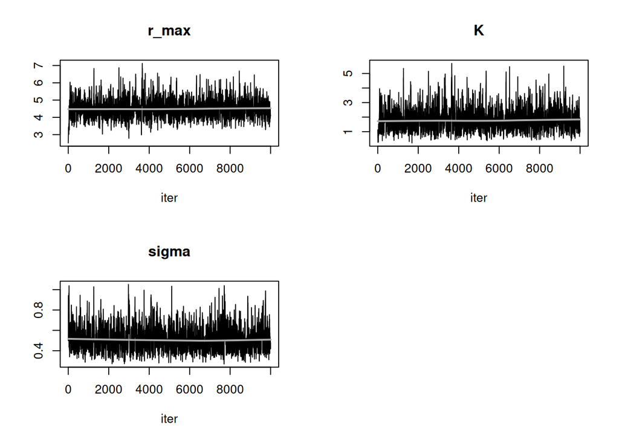

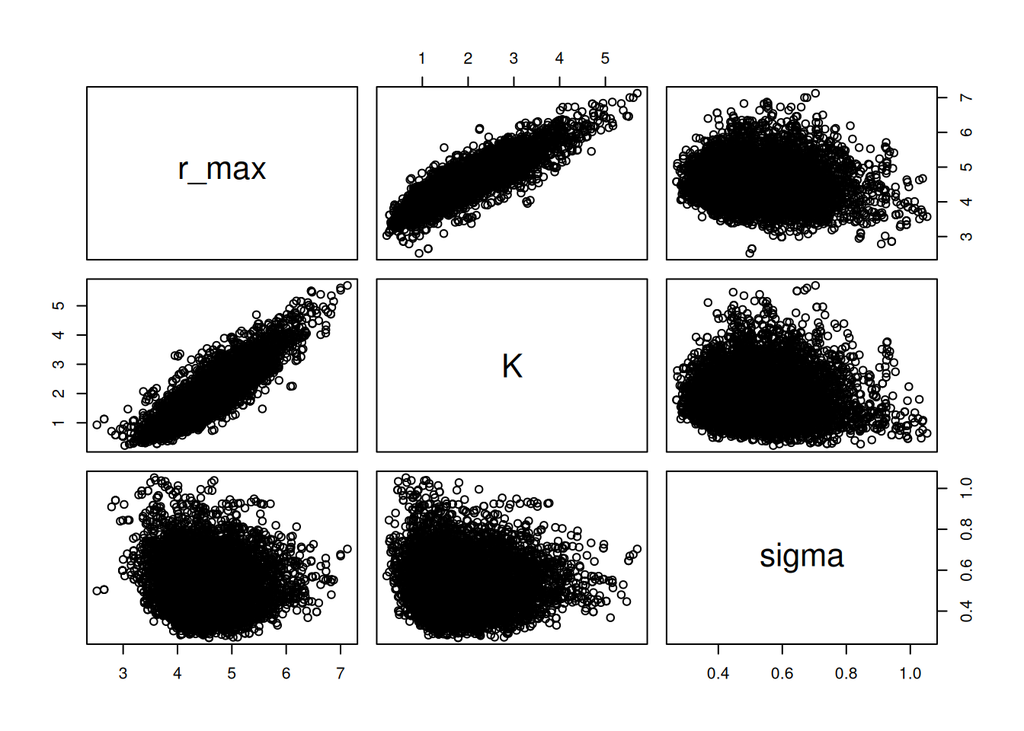

```r
## plot chains
plot(AMDR)

## 2d marginals
pairs(AMDR$pars)
```

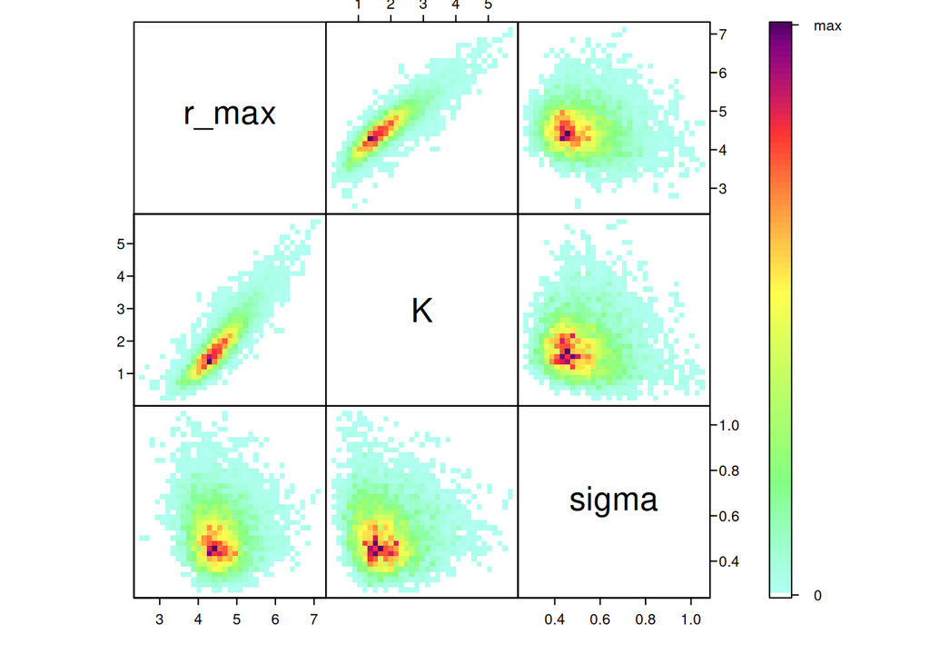

```r
IDPmisc::ipairs(AMDR$pars)
```

### Julia

```julia
using ComponentArrays
using AdaptiveMCMC
using MCMCChains
using Plots
using StatsPlots

θinit = ComponentVector(r_max = 2.5, K=1.4, sigma=0.25) # use prior mean
```

```
## ComponentVector{Float64}(r_max = 2.5, K = 1.4, sigma = 0.25)
```

```julia
res = adaptive_rwm(θinit, logposterior_monod,
                   10_000;
                   algorithm = :am,
                   b=1,   # length of burn-in. Set to 1 for no burn-in.
                   );
# convert to MCMCChains for summary and plotting
chn = Chains(res.X', labels(θinit))
```

```
## Chains MCMC chain (10000×3×1 reshape(adjoint(::Matrix{Float64}), 10000, 3, 1) with eltype Float64):
##
## Iterations        = 1:1:10000
## Number of chains  = 1
## Samples per chain = 10000
## parameters        = r_max, K, sigma
##
## Summary Statistics
##   parameters      mean       std      mcse   ess_bulk   ess_tail      rhat   ess_per_sec
##       Symbol   Float64   Float64   Float64    Float64    Float64   Float64       Missing
##
##        r_max    4.3717    0.3405    0.0199   300.0615   505.5602    1.0043       missing
##            K    1.6202    0.4665    0.0235   390.7458   586.2374    1.0019       missing
##        sigma    0.4740    0.0781    0.0035   612.7185   656.2937    1.0159       missing
##
## Quantiles
##   parameters      2.5%     25.0%     50.0%     75.0%     97.5%
##       Symbol   Float64   Float64   Float64   Float64   Float64
##
##        r_max    3.7707    4.1370    4.3465    4.5857    5.0796
##            K    0.8637    1.2965    1.5559    1.8872    2.7485
##        sigma    0.3534    0.4228    0.4642    0.5155    0.6391
```

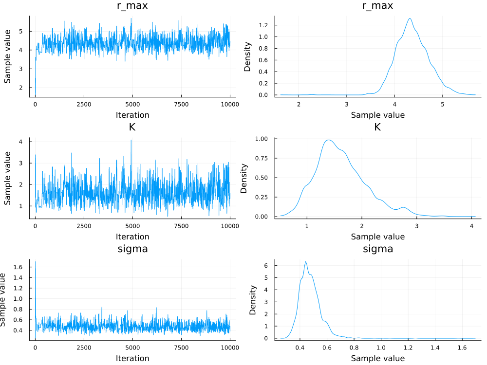

```julia
plot(chn)
```

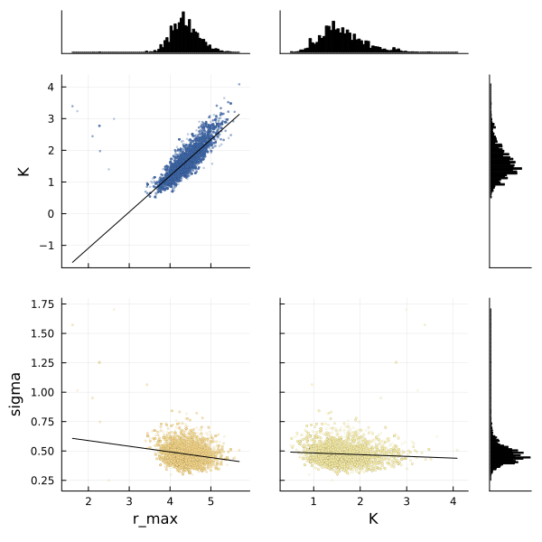

```julia
corner(chn)
```

# 2. Robust adaptive Metropolis ★

The robust adaptive Metropolis algorithm proposed by [Vihola (2012)](http://dx.doi.org/10.1007/s11222-011-9269-5) is often a good choice. It adapts the scale and rotation of the covariance matrix until it reaches a predefined acceptance rate.

- Did the algorithm reach the desired acceptance rate?
- How is the covariance matrix after the adaptation different from the initial covariance that you provided?

## Hints

### R

The package [`adaptMCMC`](https://cran.r-project.org/web/packages/adaptMCMC/index.html) provides the function `MCMC`. If the parameter `adapt` is set to `TRUE` it implements the adaptation propsoed by Vihola. Again examine the effect of the adaptation settings on the chains, in particular examining the first part of the chain to see how the adaptation works. Here the adaptation is determined by parameter `acc.rate`. Try values between 0.1 and 1.

How is the influence on the burn-in? What happens, if you use a very bad initial value?

```r
RAM <- MCMC(
    p        = logposterior.monod,
    n        = 10000,
    init     = par.start,
    scale    = jump.cov,
    adapt    = TRUE,
    acc.rate = 0.5
)

str(RAM)
```

### Julia

The package [`AdaptMCMC`](https://mvihola.github.io/docs/AdaptiveMCMC.jl/) provides multiple MCMC algorithms including the robust adaptive Metropolis.

```julia
using ComponentArrays
using AdaptiveMCMC
using MCMCChains
using Plots
using StatsPlots

θinit = ComponentVector(r_max=..., K=..., sigma=...)

res = adaptive_rwm(θinit, logposterior_monod,
                   10_000;
                   algorithm = :ram,
                   b=1,   # length of burn-in. Set to 1 for no burn-in.
                   );

# convert to MCMCChains for summary and plotting
chn = Chains(res.X', labels(θinit))

plot(chn)
corner(chn)
```

## Solution

### R

```r
library(adaptMCMC)
library(IDPmisc)
```

The mean of the prior seems to be a reasonable point to start the sampler. Alternatively, we could try to find the point of the maximum posterior density with an optimizer. For the covariance matrix of the jump distribution we use the standard deviation of the prior and assume independence.

```r
par.init <- prior.monod.mean
jump.cov <- diag(prior.monod.sd/2)

RAM <- adaptMCMC::MCMC(p        = logposterior.monod,
                       n        = 10000,
                       init     = par.init,
                       scale    = jump.cov,
                       adapt    = TRUE,
                       acc.rate = 0.5,
                       showProgressBar = FALSE)
```

```
##   generate 10000 samples
```

The acceptance rate is matched closely:

```r
RAM$acceptance.rate
```

```
## [1] 0.499
```

The adapted covariance matrix has a lot of correlation between $r_{max}$ and $K$:

```r
RAM$cov.jump
```

```
##              [,1]         [,2]         [,3]
## [1,]  0.035804476  0.040190851 -0.001527259
## [2,]  0.040190851  0.062062389 -0.002095811
## [3,] -0.001527259 -0.002095811  0.001867231
```

```r
cov2cor(RAM$cov.jump) # rescale as correlation matrix
```

```
##            [,1]       [,2]       [,3]
## [1,]  1.0000000  0.8525980 -0.1867863
## [2,]  0.8525980  1.0000000 -0.1946879
## [3,] -0.1867863 -0.1946879  1.0000000
```

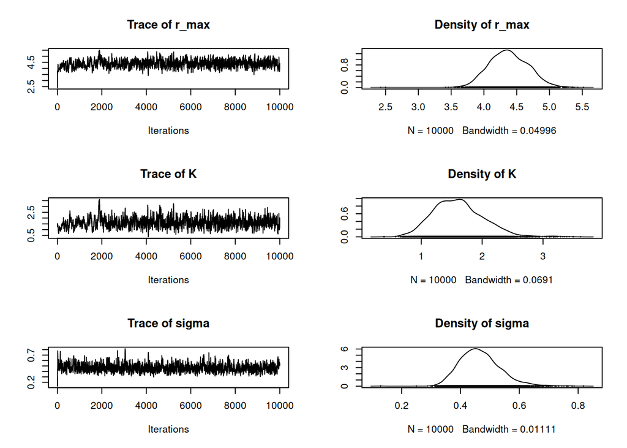

```r
## plot chains
samp.coda <- convert.to.coda(RAM)
plot(samp.coda)
```

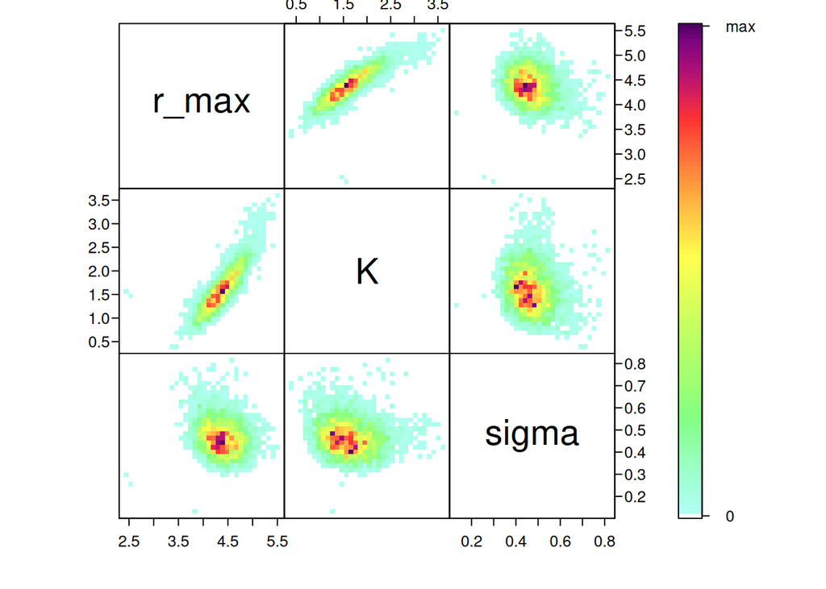

```r
## 2d marginals
IDPmisc::ipairs(RAM$samples) # prettier versions of pairs()
```

### Julia

```julia
using ComponentArrays
using AdaptiveMCMC
using MCMCChains
using Plots
using StatsPlots

θinit = ComponentVector(r_max = 2.5, K=1.4, sigma=0.25) # use prior mean
```

```
## ComponentVector{Float64}(r_max = 2.5, K = 1.4, sigma = 0.25)
```

```julia
res = adaptive_rwm(θinit, logposterior_monod,
                   10_000;
                   algorithm = :ram,
                   b=1,   # length of burn-in. Set to 1 for no burn-in.
                   );
# convert to MCMCChains for summary and plotting
chn = Chains(res.X', labels(θinit))
```

```
## Chains MCMC chain (10000×3×1 reshape(adjoint(::Matrix{Float64}), 10000, 3, 1) with eltype Float64):
##
## Iterations        = 1:1:10000
## Number of chains  = 1
## Samples per chain = 10000
## parameters        = r_max, K, sigma
##
## Summary Statistics
##   parameters      mean       std      mcse   ess_bulk    ess_tail      rhat   ess_per_sec
##       Symbol   Float64   Float64   Float64    Float64     Float64   Float64       Missing
##
##        r_max    4.4011    0.3192    0.0115   780.8894   1056.5858    1.0061       missing
##            K    1.6416    0.4356    0.0158   768.5742   1035.3708    1.0015       missing
##        sigma    0.4720    0.0771    0.0026   845.9607   1062.0448    0.9999       missing
##
## Quantiles
##   parameters      2.5%     25.0%     50.0%     75.0%     97.5%
##       Symbol   Float64   Float64   Float64   Float64   Float64
##
##        r_max    3.7844    4.1896    4.4059    4.5944    5.0781
##            K    0.8736    1.3557    1.6069    1.9022    2.5927
##        sigma    0.3593    0.4206    0.4595    0.5125    0.6415
```

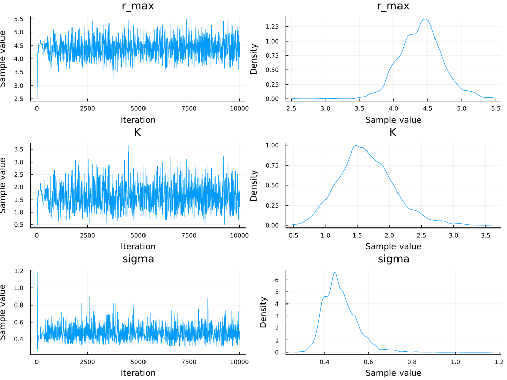

```julia
plot(chn)
```

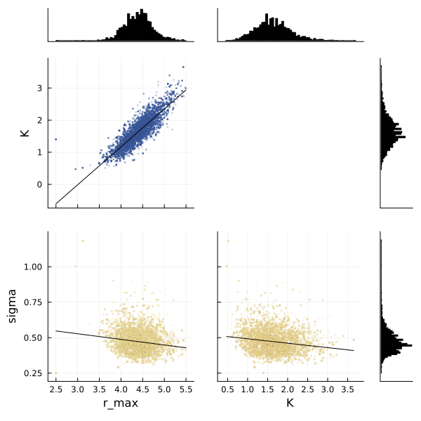

```julia
corner(chn)
```

# 3. Population based sampler ★

Population based samplers do not have an explicit jump distribution. Instead, they run multiple chains (often called *particles* or *walkers* in this context) in parallel and the proposals are generated based on the position of the other particles.

A popular algorithm of this class is the Affine-Invariant MCMC population sampler proposed by [Goodman and Weare (2010)](https://msp.org/camcos/2010/5-1/camcos-v5-n1-p04-p.pdf). The algorithm is often called *EMCEE* based on the python package with the same name.

## Hints

### R

Population based samplers are implemented in the package `mcmcensemble` as `MCMCEnsemble`. It has two methods: *stretch move* (`method = "stretch"`) and *differential evolution* (`method = "differential.evolution"`).

```r
EMCEE <- MCMCEnsemble(
    f           = logposterior.monod,
    lower.inits = par.start.lower,
    upper.inits = par.start.upper,
    max.iter    = 10000,
    n.walkers   = n.walkers,
    method      = "stretch",
    coda        = FALSE
)
```

- How do you choose `par.start.lower` and `par.start.upper`? Better wide or narrow?
- What is the influence of the number of walkers?
- Which method works better in this case?

### Julia

We use the package [`KissMCMC`](https://github.com/mauro3/KissMCMC.jl) which provides a function `emcee`:

```julia
using ComponentArrays
using KissMCMC: emcee
using Plots
using StatsPlots

# number of walkers (parallel chains)
n_walkers = 10

## We need a vector of inital values, one for each walkers.
## Make sure that they do not start from the same point.
θinits = [θinit .* rand(3) for _ in 1:n_walkers]

# Run sampler
samples, acceptance_rate, lp = emcee(logposterior_monod,
                                     θinits;
                                     niter = 10_000, # total number of density evaluations
                                     nburnin = 0);

# This looks a bit ugly. It just converts the result into
# a `MCMCChains.Chains` object for plotting.
X = permutedims(
    cat((hcat(samples[i]...) for i in 1:n_walkers)..., dims=3),
    [2, 1, 3]);
chn = Chains(X, labels(θinit))

# plotting
plot(chn)
corner(chn)
```

- How do you define the initial values? Very similar or very different?
- What is the influence of the number of walkers?

## Solution

### R

```r
library(mcmcensemble)
```

For each walker (chain) an initial starting point must be defined. In general, it is better to choose it in a region with high density. We could use an optimizer to fine the mode, but here we just use a rather wide coverage.

```r
n.walkers <- 20
par.inits <- data.frame(r.max = runif(n.walkers, 1, 10),
                        K     = runif(n.walkers, 0, 5),
                        sigma = runif(n.walkers, 0.05, 2))
```

```r
EMCEE <- MCMCEnsemble(
    f           = logposterior.monod,
    inits       = par.inits,
    max.iter    = 10000,
    n.walkers   = n.walkers,
    method      = "stretch",
    coda        = TRUE
)
```

```
## Using stretch move with 20 walkers.
```

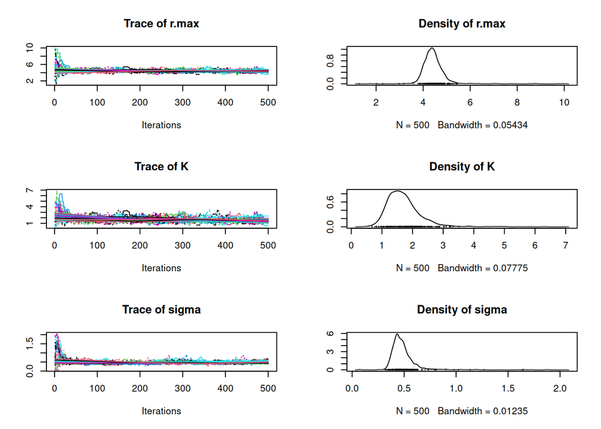

```r
plot(EMCEE$samples)
```

Note, the more walkers (chains) we have, the shorter the chains. This means we have to “pay” the burn in for every single chain. Therefore, going too extreme with the number of chains is not beneficial.

```r
n.walkers <- 1000
par.inits <- data.frame(r.max = runif(n.walkers, 1, 10),
                        K     = runif(n.walkers, 0, 5),
                        sigma = runif(n.walkers, 0.05, 2))

EMCEE <- MCMCEnsemble(
    f           = logposterior.monod,
    inits       = par.inits,
    max.iter    = 10000,
    n.walkers   = n.walkers,
    method      = "stretch",
    coda        = TRUE
)
```

```
## Using stretch move with 1000 walkers.
```

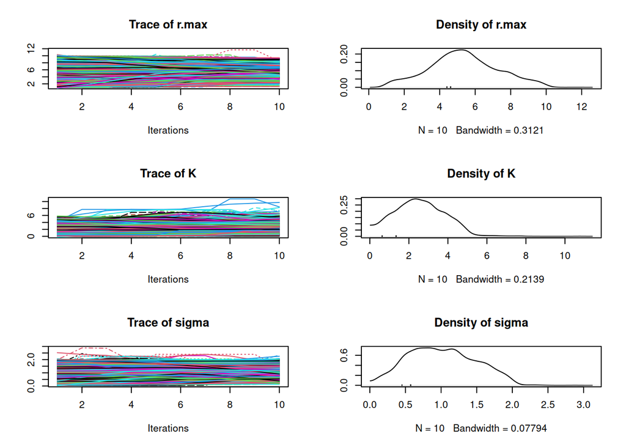

```r
plot(EMCEE$samples)
```

### Julia

```julia
using ComponentArrays
using KissMCMC: emcee
using Plots
using StatsPlots

# number of walkers (parallel chains)
n_walkers = 10;

## We need a vector of inital values, one for each walkers.
θinit = ComponentVector(r_max = 2.5, K=1.4, sigma=0.25); # prior mean
```

```
## ComponentVector{Float64}(r_max = 2.5, K = 1.4, sigma = 0.25)
```

```julia
## We add some randomnesses to make sure that they do not start
## from the same point.
θinits = [θinit .* rand(Normal(0, 0.1), 3) for _ in 1:n_walkers];

# Run sampler
samples, acceptance_rate, lp = emcee(logposterior_monod,
                                     θinits;
                                     niter = 10_000, # total number of density evaluations
                                     nburnin = 0);

# Converting into `MCMCChains.Chains` object for plotting.
X = permutedims(
    cat((hcat(samples[i]...) for i in 1:n_walkers)..., dims=3),
    [2, 1, 3]);
chn = Chains(X, labels(θinit))
```

```
## Chains MCMC chain (1000×3×10 Array{Float64, 3}):
##
## Iterations        = 1:1:1000
## Number of chains  = 10
## Samples per chain = 1000
## parameters        = r_max, K, sigma
##
## Summary Statistics
##   parameters      mean       std      mcse   ess_bulk   ess_tail      rhat   ess_per_sec
##       Symbol   Float64   Float64   Float64    Float64    Float64   Float64       Missing
##
##        r_max    4.2305    0.8310    0.0706   134.8128   156.3894    1.0676       missing
##            K    1.7308    0.7436    0.0421   310.3074   313.1726    1.0406       missing
##        sigma    0.5234    0.2632    0.0213   184.3999   161.5749    1.0490       missing
##
## Quantiles
##   parameters      2.5%     25.0%     50.0%     75.0%     97.5%
##       Symbol   Float64   Float64   Float64   Float64   Float64
##
##        r_max    0.8053    4.1580    4.3734    4.5834    5.0911
##            K    0.7930    1.3351    1.6029    1.9164    3.9049
##        sigma    0.3297    0.4163    0.4644    0.5349    1.4972
```

Note, that our chains are only of length 1000. So we have a lot of computation used for the burn-in phase.

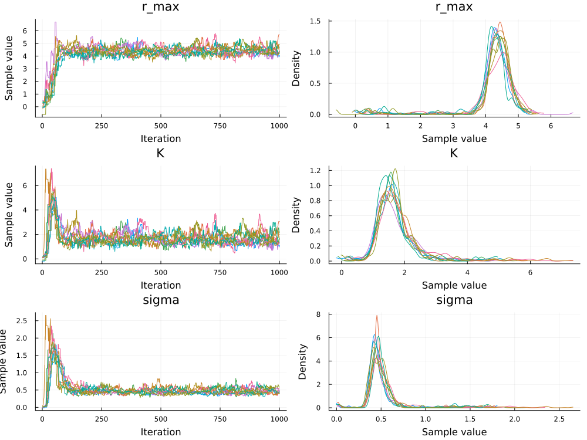

```julia
# plotting
plot(chn)
```

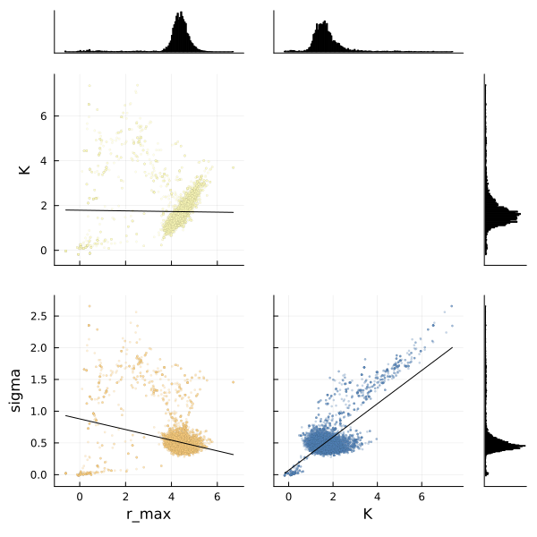

```julia
corner(chn)
```

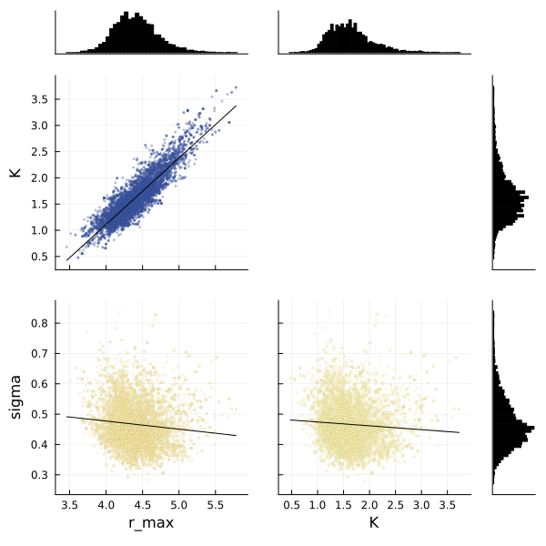

```julia
# removing burn-in:
corner(chn[250:end,:,:])
```

# 4. Posterior Predictions ★

In many cases we want to make predictions for new model inputs. Let’s say we have observed the data $(y, x)$ and used it to infer the posterior $p(\theta | y, x)$. We would now like to make predictions given a new input $x^*$ using the learned posterior distribution:

$$p(Y^* | x^*, y, x,) = \int p(Y^* |
x^*, \theta) \, p(\theta | y, x)
\text{d}\theta$$

- For the monod model, what is $p(Y^* | x^*, \theta)$?
- Produce predictions for the monod model for $C = \{10, 12, 14, 16\}$ using a posterior sample from a exercises. We only need samples form the predictive distribution. How can you do this without solving the integral analytically?
- Plot the result with 90% prediction interval.
- How much do you trust that the interval is correct? What assumptions did you make?

## Solution

- The expression $p(Y^* | x^*, \theta)$ is our probabilistic model, so the distribution of $Y^*$ given some inputs and parameters (i.e. the likelihood function).
- Typically we do not have the posterior distribution $p(\theta | y, x)$ in analytical form but a sample from it. Hence we cannot compute the integral over all $\theta$ (besides that this would be difficult anyway). Instead, we use an approach to obtain samples from $Y^*$:
  1. Take a sample $\theta'$ from $p(\theta | y, x)$.
  2. Take a sample from $p(Y^* | x^*, \theta')$.

  Both steps are computationally cheap. For 1) we already have samples from the parameter inference, and 2) is simply a forward simulation of the model as we did in exercises 1. Hence, producing posterior predictions is much cheaper than inference.

  (Technically we sample from the joint distribution $p(Y^*, \theta| x^*, y, x)$). The marginalization over $\theta$ is done by simply ignoring the sampled $\theta$s and looking only at $Y^*$.)
- It is important to keep in mind that the resulting prediction intervals are only correct as long the underlying model is correct! For example, it seems rather risky to extrapolate with the monod model to large concentrations outside of the calibration data range.

### R

We take the function for forward simulations from exercises 1:

```r
simulate.monod.stoch <- function(par, C){
    ## run model
    r.det <- model.monod(par, C)

    ## generate noise
    z <- rnorm(length(C), 0, par["sigma"])

    return(r.det + z)
}
```

```r
m <- 1000 # number of samples

Cstar <- c(10, 12, 14, 16)               # new inputs

## posterior samples, removing burn-in
post.samples <- RAM$samples[1000:10000,]

Ystar <- matrix(NA, ncol=length(Cstar), nrow=m)
colnames(Ystar) <- paste0("C_", Cstar)
for(k in 1:m){
    ## 1) take a sample from posterior
    i <- sample(ncol(post.samples), 1)
    theta <- post.samples[i,]

    ## 2) forward simulation from model
    Ystar[k,] <- simulate.monod.stoch(theta, Cstar)
}
```

We can also plots the predictions with uncertainty bands:

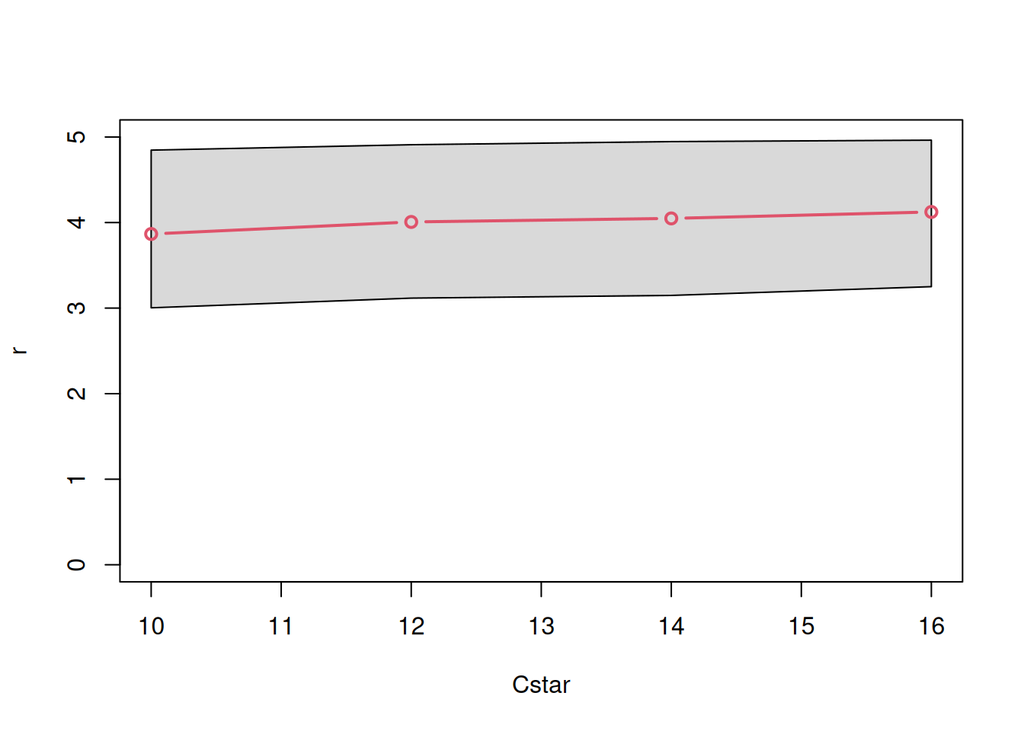

```r
Ystar.quants <- apply(Ystar, MARGIN=2, FUN=quantile, probs=c(0.05, 0.5, 0.95))

## plot result
plot(Cstar, Ystar.quants[2,], ylab="r", ylim=c(0, 5))
polygon(c(Cstar,rev(Cstar)), c(Ystar.quants[1,],rev(Ystar.quants[3,])), col = "grey85")
lines(Cstar, Ystar.quants[2,], col=2, lwd=2, type="b")
```

### Julia

We take the function for forward simulations from exercises 1:

```julia
# function to simulate stochastic realisations
function simulate_monod_stoch(C, par)
    Ydet = model_monod(C, par)
    z = rand(Normal(0, par.sigma), length(Ydet)) # adding noise
    Ydet .+ z
end
```

```
## simulate_monod_stoch (generic function with 1 method)
```

```julia
m = 1000
```

```
## 1000
```

```julia
Cstar = [10,12,14,16]
```

```
## 4-element Vector{Int64}:
##  10
##  12
##  14
##  16
```

```julia
Ystar = Matrix{Float64}(undef, m, length(Cstar));
θ = copy(θinit);
for k in 1:m
    i = rand(1000:10000)
    θ .= res.X[:,i]
    Ystar[k,:] = simulate_monod_stoch(Cstar, θ)
end
```

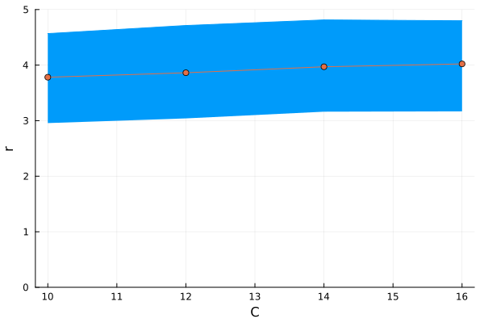

```julia
# compute quantile
low_quantile = [quantile(Ystar[:,i], 0.05) for i in 1:length(Cstar)];
med_quantile = [quantile(Ystar[:,i], 0.5) for i in 1:length(Cstar)];
upper_quantile = [quantile(Ystar[:,i], 0.95) for i in 1:length(Cstar)];
plot(Cstar, upper_quantile,
     fillrange = low_quantile,
     labels = false,
     xlabel = "C",
     ylabel = "r",
     ylim=(0,5));
plot!(Cstar, med_quantile, marker=:circle,
      labels = false)
```

# 5. Gradient based samplers ♛

If we are able to compute the gradient of the log density, $\nabla \log p$, we can use much more efficient sampling methods. For small numbers of parameters this may not be relevant, for lager problems (more than 20 dimensions) the differences can be huge.

Julia is particularly well suited for these applications, because many libraries for Automatic Differentiation (AD) are available - methods that compute the gradient of (almost) any Julia function by analyzing the code.

Because there is no equally powerful AD available in R, we can do this exercise only with Julia.

## Parameter transformation

Most gradient based samplers assume that all parameters are in $\mathbb{R}$. If we have a parameter that is only defined on an interval, such as a standard deviation that is never negative, we need to transform the model parameter before sampling. For this we need three ingredients:

- a function that maps every vector in $\mathbb{R}^n$ to our “normal” model parameter space,
- the inverse of this function,
- the determinant of the Jacobian of this function.

The package [TransformVariables](https://github.com/tpapp/TransformVariables.jl) helps us with these transformations. We need a function that takes a vector in $\mathbb{R}^n$ to evaluate the posterior.

```julia
using TransformVariables

# defines the 'legal' parameter space, all parameter cannot be negative
# due to the lognormal prior
trans = as((r_max = asℝ₊, K = asℝ₊, sigma = asℝ₊))

# define a function that takes a parameter vector in ℝ^n
function logposterior_monod_Rn(par_Rn)
    # transforms from ℝ^n to parameter space,
    # and compute log of the determinante of the jacobian
    par, logjac = TransformVariables.transform_and_logjac(trans, par_Rn)

    # do not forget to add the log determinante!
    logposterior_monod(ComponentVector(par)) + logjac
end
```

We can now sample in $\mathbb{R}^n$ and later transform the samples to the model parameter space with:

```julia
TransformVariables.transform(trans, [-1,-1,-1]) # -> (r_max=0.367, K=0.367, sigma=0.367)
```

## Automatic Differentation

The last ingredient we need is a function that computes the gradient of `logposterior_monod_Rn`. To do so we need to differentiate through our model, the likelihood, the prior, the parameter transformation, and the determinant of the Jaccobian. Needles to say, even for our very simple model this would be very tedious to do manually!

Instead we use [Automatic Differentiation (AD)](https://en.wikipedia.org/wiki/Automatic_differentiation). Julia has [multiple packages](https://juliadiff.org/) for AD that make different trade-offs. We use [`ForwardDiff`](https://github.com/JuliaDiff/ForwardDiff.jl) that is well suited for smaller dimensions.

AD requires all your model code to be implemented in pure Julia! Otherwise there are few restrictions. For example, you can compute the gradient of the *growth* model even though it uses an advanced adaptive ODE solver internally.

```julia
import ForwardDiff

# derive a function that computes the gradient
∇logposterior_monod_Rn(par_Rn) = ForwardDiff.gradient(logposterior_monod_Rn, par_Rn)

# make sure that you can run both functions for all values in ℝ^n
par_test = randn(3)
logposterior_monod_Rn(par_test)
∇logposterior_monod_Rn(par_test)
```

## Hamiltonian Monte Carlo

Hamiltonian Monte Carlo (HMC) is one of the most powerful methods to sample in high dimensions. The “No-U-Turn Sampler” (NUTS) is a popular version. For example, it is used in [*STAN*](https://mc-stan.org/).

The package [`AdvancedHMC`](https://github.com/TuringLang/AdvancedHMC.jl) provides building blocks that can be combined to construct various HMC samplers. The function is a wrapper that provides a NUTS sampler as implemented in STAN.

````julia
using AdvancedHMC

"""
# NUTS HMC sampler as used by STAN
Based on the documentation of AdvancedHMC.jl

```Julia
stanHMC(lp::Function, ∇lp::Function,  θ_init;
        n_samples::Int=1000, n_adapts::Int=n_samples÷2)
```

### Arguments
- `lp`:  log density to sample from (up to a constant)
- `∇lp`: define how to get the log gradient of `lp`.
- `n_samples::Int=1000`: number of samples
- `n_adapts::Int=n_samples÷2`: length of adaptation

### Return Value
A named tuple with fields:
- `samples`: array containing the samples
- `stats`: contains various statistics form the sampler. See AdvancedHMc documentation.
"""
function stanHMC(lp::Function, ∇lp::Function,  θ_init,;
                 n_samples::Int=1000, n_adapts::Int=n_samples÷2)

    # Define a Hamiltonian system
    D = length(θ_init)   # number of parameters
    metric = DiagEuclideanMetric(D)
    hamiltonian = Hamiltonian(metric, lp, θr -> (lp(θr), ∇lp(θr)))

    # Define a leapfrog solver, with initial step size chosen heuristically
    initial_ϵ = find_good_stepsize(hamiltonian, θ_init)
    integrator = Leapfrog(initial_ϵ)

    # Define an HMC sampler, with the following components
    #   - multinomial sampling scheme,
    #   - generalised No-U-Turn criteria, and
    #   - windowed adaption for step-size and diagonal mass matrix
    proposal = NUTS{MultinomialTS, GeneralisedNoUTurn}(integrator)
    adaptor = StanHMCAdaptor(MassMatrixAdaptor(metric), StepSizeAdaptor(0.8, integrator))

    # -- run sampler
    samples, stats = sample(hamiltonian, proposal, θ_init, n_samples,
                            adaptor, n_adapts; progress=true)

    return (samples=samples, stats=stats)

end
````

HMC samplers need many density- and gradient-evaluations to produce a single proposal. However, the acceptance rate of an HMC sampler should be close to one. We can use the wrapper function `stanHMC` like this:

```julia
par_init = [-1.0, -1.0, -1.0]   # in ℝⁿ
res = stanHMC(logposterior_monod_Rn,
              ∇logposterior_monod_Rn,
              par_init;
              n_samples = 100);

res.samples                     # this are the samples in ℝⁿ !
```

The samples we get are in $\mathbb{R}^n$. Before we have a look, let’s transform them to the “normal” parameter space:

```julia
# Transform the samples to the "normal" space and convert to `Chains`
_chn = [ComponentVector(TransformVariables.transform(trans, res.samples[i]))
        for i in 1:size(res.samples, 1)];
chn = Chains(_chn,  [:r_max, :K, :sigma])

plot(chn)
corner(chn)
```

## BarkerMCMC

[Livingstone and Zanella (2021)](https://doi.org/10.1111/rssb.12482) proposed a comparably simple MCMC algorithm that uses the gradient to adapt the jump distribution. It is a promising alternative to HMC in cases where the number of parameters is not very high, or if the gradient is expected to be noisy (which is often the case if a model uses adaptive ODE solvers).

[`BarkerMCMC.jl`](https://github.com/scheidan/BarkerMCMC.jl) implements it including an adaptation that aims at a given acceptance rate.

```julia
using BarkerMCMC: barker_mcmc

par_init = [-1.0, -1.0, -1.0]   # in ℝⁿ

# see `?barker_mcmc` for all options
res = barker_mcmc(logposterior_monod_Rn,
                  ∇logposterior_monod_Rn,
                  par_init;
                  n_iter = 1000,
                  target_acceptance_rate=0.4);

res.samples                     # this are the samples in ℝⁿ !
res.log_p
```

The samples we get are in $\mathbb{R}^n$. Before we have a look, let’s transform them to the “normal” parameter space:

```julia
using MCMCChains
using StatsPlots

# Transform the samples to the "normal" space and convert to `Chains`
_chn = [ComponentVector(TransformVariables.transform(trans, res.samples[i,:]))
        for i in 1:size(res.samples, 1)];
chn = Chains(_chn,  [:r_max, :K, :sigma])

plot(chn)
corner(chn)
```

## Solution

### Julia

First we make sure, that we can sample in an unlimited space by using appropriate transformations:

```julia
using TransformVariables

# defines the 'legal' parameter space, all parameter cannot be negative
# due to the lognormal prior
trans = as((r_max = asℝ₊, K = asℝ₊, sigma = asℝ₊))
```

```
## [1:3] NamedTuple of transformations
##   [1:1] :r_max → asℝ₊
##   [2:2] :K → asℝ₊
##   [3:3] :sigma → asℝ₊
```

```julia
# define a function that takes a parameter vector in ℝ^n
function logposterior_monod_Rn(par_Rn)
    # transforms from ℝ^n to parameter space,
    # and compute log of the determinante of the jacobian
    par, logjac = TransformVariables.transform_and_logjac(trans, par_Rn)

    # do not forget to add the log determinante!
    logposterior_monod(ComponentVector(par)) + logjac
end
```

```
## logposterior_monod_Rn (generic function with 1 method)
```

We get the gradient of the logposterior with AD:

```julia
import ForwardDiff

# derive a function that computes the gradient
∇logposterior_monod_Rn(par_Rn) = ForwardDiff.gradient(logposterior_monod_Rn, par_Rn)
```

```
## ∇logposterior_monod_Rn (generic function with 1 method)
```

#### HMC

```julia
using AdvancedHMC
function stanHMC(lp::Function, ∇lp::Function,  θ_init,;
                 n_samples::Int=1000, n_adapts::Int=n_samples÷2)

    # Define a Hamiltonian system
    D = length(θ_init)   # number of parameters
    metric = DiagEuclideanMetric(D)
    hamiltonian = Hamiltonian(metric, lp, θr -> (lp(θr), ∇lp(θr)))

    # Define a leapfrog solver, with initial step size chosen heuristically
    initial_ϵ = find_good_stepsize(hamiltonian, θ_init)
    integrator = Leapfrog(initial_ϵ)

    # Define an HMC sampler, with the following components
    #   - multinomial sampling scheme,
    #   - generalised No-U-Turn criteria, and
    #   - windowed adaption for step-size and diagonal mass matrix
    proposal = NUTS{MultinomialTS, GeneralisedNoUTurn}(integrator)
    adaptor = StanHMCAdaptor(MassMatrixAdaptor(metric), StepSizeAdaptor(0.8, integrator))

    # -- run sampler
    samples, stats = sample(hamiltonian, proposal, θ_init, n_samples,
                            adaptor, n_adapts; progress=true)

    return (samples=samples, stats=stats)

end
```

```
## stanHMC (generic function with 1 method)
```

We use our wrapper function `stanHMC`. Note, that for HMC we typically need a much lower number of samples.

```julia
par_init = [-1.0, -1.0, -1.0]   # in ℝⁿ
```

```
## 3-element Vector{Float64}:
##  -1.0
##  -1.0
##  -1.0
```

```julia
res = stanHMC(logposterior_monod_Rn,
              ∇logposterior_monod_Rn,
              par_init;
              n_samples = 100);

res.samples                     # this are the samples in ℝⁿ !
```

```
## 100-element Vector{Vector{Float64}}:
##  [-0.7302483945436486, -1.0648163386479825, 0.48660006528145705]
##  [-0.7302483945436486, -1.0648163386479825, 0.48660006528145705]
##  [-0.6360172324745735, -0.5597915155680546, 1.0164679446227158]
##  [-0.6204671205521705, -0.5512582482398937, 0.9359790456140087]
##  [-0.32561466939269174, 0.4799970242302889, 0.6908194625204152]
##  [0.023077473454521658, 0.3407097153479064, 0.8429368417912785]
##  [1.46379734184656, 0.22147829494208307, 0.1127769616542437]
##  [1.4471276957286512, 0.5754849141147844, -0.16290012922335445]
##  [1.555991338178176, 0.6138857128591254, -0.2849334212566445]
##  [1.3973258509046493, 0.22429327018658962, -0.6808480092814536]
##  ⋮
##  [1.6518543116815547, 0.6970760158722943, -0.6231915971019157]
##  [1.4194398117814193, 0.48298257701948777, -0.7155320135954206]
##  [1.4989853277083787, 0.43994391597190163, -0.7699391611985041]
##  [1.4999335634215811, 0.4926285646855976, -0.7894510152704626]
##  [1.4395185907064856, 0.2144275288993687, -0.7179860083714635]
##  [1.3214751170790857, 0.07800224442124605, -0.8161660675146613]
##  [1.7135175587450486, 1.144109069813677, -0.6989438789592555]
##  [1.366768517273734, -0.2341227335752588, -0.8116900744076089]
##  [1.4693018790567363, 0.44530913864254484, -0.7313663410518046]
```

We need to back-transform the samples to the “normal” space. For plotting we convert to `Chains`:

```julia
_chn = [ComponentVector(TransformVariables.transform(trans, res.samples[i]))
        for i in 1:size(res.samples, 1)];
chn = Chains(_chn,  [:r_max, :K, :sigma])
```

```
## Chains MCMC chain (100×3×1 Array{Float64, 3}):
##
## Iterations        = 1:1:100
## Number of chains  = 1
## Samples per chain = 100
## parameters        = r_max, K, sigma
##
## Summary Statistics
##   parameters      mean       std      mcse   ess_bulk   ess_tail      rhat   ess_per_sec
##       Symbol   Float64   Float64   Float64    Float64    Float64   Float64       Missing
##
##        r_max    4.0975    0.9421    0.3155    23.8454    12.7391    1.0579       missing
##            K    1.4715    0.4699    0.0926    24.8764    16.8447    1.0928       missing
##        sigma    0.5968    0.4212    0.1380    14.6294    19.1665    1.0646       missing
##
## Quantiles
##   parameters      2.5%     25.0%     50.0%     75.0%     97.5%
##       Symbol   Float64   Float64   Float64   Float64   Float64
##
##        r_max    0.5333    4.0313    4.2610    4.4599    5.0273
##            K    0.5737    1.2034    1.4373    1.6752    2.4225
##        sigma    0.3734    0.4333    0.4849    0.5537    2.1675
```

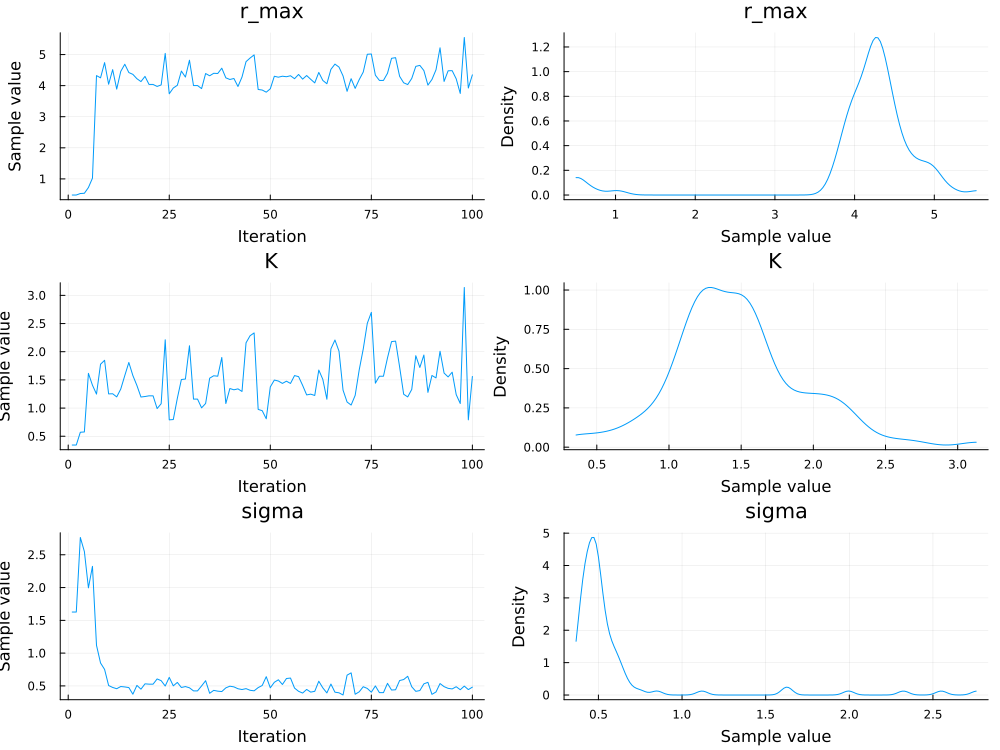

```julia
plot(chn)
```

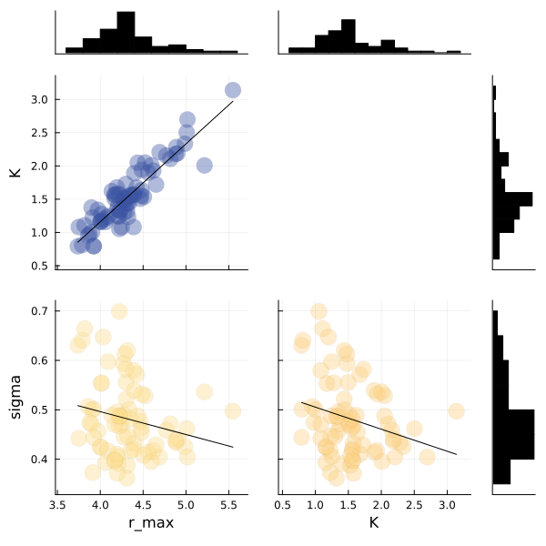

```julia
corner(chn[25:end,:,:])
```

#### BarkerMCMC

The same steps are taken for the `BarkerMCMC`:

```julia
using BarkerMCMC: barker_mcmc

par_init = [-1.0, -1.0, -1.0];   # in ℝⁿ
```

```
## 3-element Vector{Float64}:
##  -1.0
##  -1.0
##  -1.0
```

```julia
# see `?barker_mcmc` for all options
res = barker_mcmc(logposterior_monod_Rn,
                  ∇logposterior_monod_Rn,
                  par_init;
                  n_iter = 1000,
                  target_acceptance_rate=0.4);
# Transform the samples to the "normal" space and convert to `Chains`
_chn = [ComponentVector(TransformVariables.transform(trans, res.samples[i,:]))
        for i in 1:size(res.samples, 1)];
chn = Chains(_chn,  [:r_max, :K, :sigma])
```

```
## Chains MCMC chain (1000×3×1 Array{Float64, 3}):
##
## Iterations        = 1:1:1000
## Number of chains  = 1
## Samples per chain = 1000
## parameters        = r_max, K, sigma
##
## Summary Statistics
##   parameters      mean       std      mcse   ess_bulk   ess_tail      rhat   ess_per_sec
##       Symbol   Float64   Float64   Float64    Float64    Float64   Float64       Missing
##
##        r_max    4.3690    0.4358    0.0738    47.5639    32.6461    1.0118       missing
##            K    1.6148    0.4795    0.0732    37.3265    12.7563    1.0092       missing
##        sigma    0.4909    0.1716    0.0326    60.5549    36.5404    1.0179       missing
##
## Quantiles
##   parameters      2.5%     25.0%     50.0%     75.0%     97.5%
##       Symbol   Float64   Float64   Float64   Float64   Float64
##
##        r_max    3.7270    4.1404    4.3931    4.6057    5.0627
##            K    0.7736    1.3013    1.5637    1.9152    2.5653
##        sigma    0.3529    0.4270    0.4620    0.5234    0.6852
```

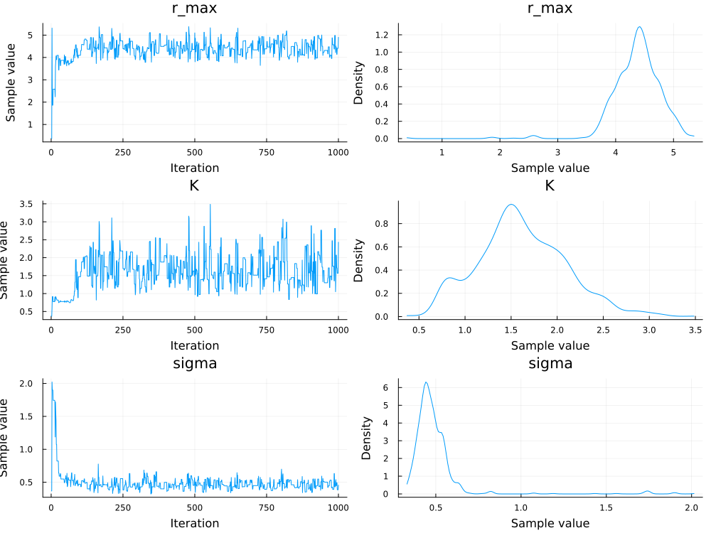

```julia
plot(chn)
```

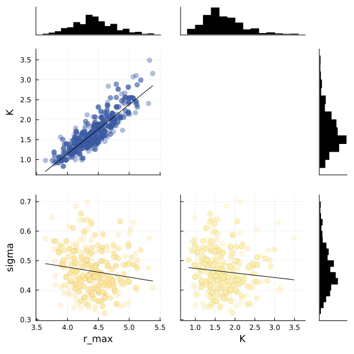

```julia
corner(chn[250:end,:,:])
```